# What’s news

[figure not shown]

##### Workshop on the Chikungunya Situation in France and Italy

Workshop

Learning

The Department of Surveillance, Warning, Preparedness, and Emergency Response organized an internal workshop to update team members on the current Chikungunya situation in…

Tuyen Pham

Dec 5, 2025

[figure not shown]

##### Workshop on Collaboration with OUCRU for Rt Research in Dengue

Workshop

Learning

The Department of Surveillance, Warning, Preparedness, and Emergency Response recently held a workshop to present the research concept on the time-varying reproduction…

Tuyen Pham

Dec 5, 2025

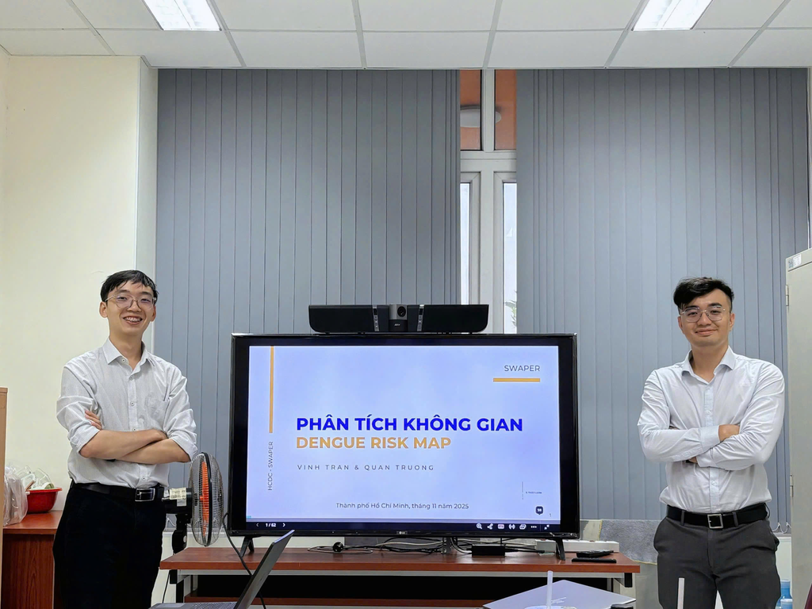

##### Workshop Spatial Analysis and Risk map

Workshop

Learning

Recently, the Department organized a workshop on “Spatial Analysis” with the participation of members from the Surveillance and Early Warning Division (GSCB). The session…

Tuyen Pham

Dec 5, 2025

[figure not shown]

##### Workshop Introducing the RRT Management Tool

Workshop

Learning

Tuyen Pham

Dec 5, 2025

[figure not shown]

##### Workshop on Using the EIOS System for Monitoring Public Health Events

Workshop

Learning

The Department of Surveillance, Warning, Preparedness, and Emergency Response organized an internal workshop on the Epidemic Intelligence from Open Sources (EIOS) system to…

Tuyen Pham

Dec 5, 2025

[figure not shown]

##### Workshop on “Transmission Assessment” Held by the Department

Workshop

Learning

The Department recently organized a workshop titled “Transmission Assessment” with the participation of staff members across the unit. The session focused on providing…

Tuyen Pham

Dec 5, 2025

[figure not shown]

##### RECOGNIZING THE OUTSTANDING PRESENTER OF Q2/2025

Outstanding Presentation award

Congratulations to Mr. Khang - Winner of the Outstanding Presentation award for Q2/2025 !

Tuyen Pham

Jul 15, 2025

[figure not shown]

##### Meeting with OUCRU

Collaboration

Partner Meeting

Summary of the collaboration meeting between SWAPER and OUCRU to discuss infectious disease surveillance and future joint activities.

Tuyen Pham

Jul 2, 2025

Back to top